# CS 439 - Introduction to Data Science

# Course Project

## Professor : Gerard de Melo

**Name:** Smitkumar Patel  
**NetID:** Shp109  
**Group:** 06  
**Recitation:** 02  
**Email:** shp109@rutgers.edu

# Cricket Players (Cricketers) Data Analysis

## Machine Learning Algorithms

### Preprossing on Data

```python
import pandas as pd
```

Following data file is same file that I use in crouse project part1 assignment. Part1 notebook was large in size; therefore, I decided to use new notebook for part2. In addition, I have so many missing values in the dataset because few players only played in one format. For example, some players only played First-class cricket, so for those players other format entry is NaN. Therefore, I will replace other format data with zero that means the same that they did not play that format (recommended by TA)

```python
data = pd.read_csv('data/combine_all_and_ipl_playes_till_41329.csv', index_col= 0)
```

```python
preprocess_data = data.copy(deep = True)
```

```python
pd.set_option('display.max_columns', None)
pd.set_option('display.max_rows', None)
```

```python
preprocess_data.fillna(value = {'BATTING_Tests_Mat':0, 'BATTING_ODIs_Mat': 0,'BATTING_T20Is_Mat':0 ,'BATTING_First-class_Mat': 0,'BATTING_List A_Mat':0,'BATTING_T20s_Mat':0,\
                                    'BOWLING_Tests_Mat': 0, 'BOWLING_ODIs_Mat':0, 'BOWLING_T20Is_Mat':0,'BOWLING_First-class_Mat':0, 'BOWLING_List A_Mat':0,\
                                    'BOWLING_T20s_Mat': 0}, inplace=True)
```

```python
columns_test = ['BATTING_Tests_Inns', 'BATTING_Tests_Runs', 'BATTING_Tests_HS','BATTING_Tests_Ave',\
                'BATTING_Tests_BF', 'BATTING_Tests_SR','BATTING_Tests_100','BATTING_Tests_50','BATTING_Tests_4s',\
                'BATTING_Tests_6s','BATTING_Tests_Ct', 'BATTING_Tests_St']
preprocess_data.loc[preprocess_data.BATTING_Tests_Mat == 0, columns_test] = 0
```

```python
columns_ODI = ['BATTING_ODIs_Inns', 'BATTING_ODIs_Runs','BATTING_ODIs_HS','BATTING_ODIs_Ave', \
               'BATTING_ODIs_BF','BATTING_ODIs_SR', 'BATTING_ODIs_100','BATTING_ODIs_50',\
               'BATTING_ODIs_4s', 'BATTING_ODIs_6s', 'BATTING_ODIs_Ct','BATTING_ODIs_St']
preprocess_data.loc[preprocess_data.BATTING_ODIs_Mat == 0, columns_ODI] = 0
```

```python
columns_T20I = ['BATTING_T20Is_Inns','BATTING_T20Is_Runs', 'BATTING_T20Is_HS',
       'BATTING_T20Is_Ave', 'BATTING_T20Is_BF', 'BATTING_T20Is_SR',
       'BATTING_T20Is_100', 'BATTING_T20Is_50', 'BATTING_T20Is_4s',
       'BATTING_T20Is_6s', 'BATTING_T20Is_Ct', 'BATTING_T20Is_St']
preprocess_data.loc[preprocess_data.BATTING_T20Is_Mat == 0, columns_T20I] = 0
```

```python
columns_First_class = ['BATTING_First-class_Inns','BATTING_First-class_Runs',
       'BATTING_First-class_HS', 'BATTING_First-class_Ave',
       'BATTING_First-class_BF', 'BATTING_First-class_SR',
       'BATTING_First-class_100', 'BATTING_First-class_50',
       'BATTING_First-class_4s', 'BATTING_First-class_6s',
       'BATTING_First-class_Ct', 'BATTING_First-class_St']
preprocess_data.loc[preprocess_data['BATTING_First-class_Mat'] == 0, columns_First_class] = 0
```

```python
columns_ListA = ['BATTING_List A_Inns','BATTING_List A_Runs', 'BATTING_List A_HS', 'BATTING_List A_Ave',
       'BATTING_List A_BF', 'BATTING_List A_SR', 'BATTING_List A_100',
       'BATTING_List A_50', 'BATTING_List A_4s', 'BATTING_List A_6s',
       'BATTING_List A_Ct', 'BATTING_List A_St']
preprocess_data.loc[preprocess_data['BATTING_List A_Mat'] == 0, columns_ListA] = 0
```

```python
columns_T20 = ['BATTING_T20s_Inns','BATTING_T20s_Runs','BATTING_T20s_HS', 'BATTING_T20s_Ave', 'BATTING_T20s_BF',
       'BATTING_T20s_SR', 'BATTING_T20s_100', 'BATTING_T20s_50',
       'BATTING_T20s_4s', 'BATTING_T20s_6s', 'BATTING_T20s_Ct',
       'BATTING_T20s_St']
preprocess_data.loc[preprocess_data['BATTING_T20s_Mat'] == 0, columns_T20] = 0
```

```python
columns_bowler_test = ['BOWLING_Tests_Inns', 'BOWLING_Tests_Balls', 'BOWLING_Tests_Runs',
       'BOWLING_Tests_Wkts', 'BOWLING_Tests_BBI', 'BOWLING_Tests_BBM',
       'BOWLING_Tests_Ave', 'BOWLING_Tests_Econ', 'BOWLING_Tests_SR',
       'BOWLING_Tests_4w', 'BOWLING_Tests_5w', 'BOWLING_Tests_10']
preprocess_data.loc[preprocess_data['BOWLING_Tests_Mat'] == 0, columns_bowler_test] = 0
```

```python
columns_bowler_ODI = ['BOWLING_ODIs_Inns', 'BOWLING_ODIs_Balls',
       'BOWLING_ODIs_Runs', 'BOWLING_ODIs_Wkts', 'BOWLING_ODIs_BBI',
       'BOWLING_ODIs_BBM', 'BOWLING_ODIs_Ave', 'BOWLING_ODIs_Econ',
       'BOWLING_ODIs_SR', 'BOWLING_ODIs_4w', 'BOWLING_ODIs_5w',
       'BOWLING_ODIs_10']
preprocess_data.loc[preprocess_data['BOWLING_ODIs_Mat'] == 0, columns_bowler_ODI] = 0
```

```python
columns_bowler_T20I = ['BOWLING_T20Is_Inns',
       'BOWLING_T20Is_Balls', 'BOWLING_T20Is_Runs', 'BOWLING_T20Is_Wkts',
       'BOWLING_T20Is_BBI', 'BOWLING_T20Is_BBM', 'BOWLING_T20Is_Ave',
       'BOWLING_T20Is_Econ', 'BOWLING_T20Is_SR', 'BOWLING_T20Is_4w',
       'BOWLING_T20Is_5w', 'BOWLING_T20Is_10']
preprocess_data.loc[preprocess_data['BOWLING_T20Is_Mat'] == 0, columns_bowler_T20I] = 0
```

```python
columns_bowler_First_class = ['BOWLING_First-class_Inns', 'BOWLING_First-class_Balls',
       'BOWLING_First-class_Runs', 'BOWLING_First-class_Wkts',
       'BOWLING_First-class_BBI', 'BOWLING_First-class_BBM',
       'BOWLING_First-class_Ave', 'BOWLING_First-class_Econ',
       'BOWLING_First-class_SR', 'BOWLING_First-class_4w',
       'BOWLING_First-class_5w', 'BOWLING_First-class_10']
preprocess_data.loc[preprocess_data['BOWLING_First-class_Mat'] == 0, columns_bowler_First_class] = 0
```

```python
columns_bowler_ListA = ['BOWLING_List A_Inns',
       'BOWLING_List A_Balls', 'BOWLING_List A_Runs',
       'BOWLING_List A_Wkts', 'BOWLING_List A_BBI', 'BOWLING_List A_BBM',
       'BOWLING_List A_Ave', 'BOWLING_List A_Econ', 'BOWLING_List A_SR',
       'BOWLING_List A_4w', 'BOWLING_List A_5w', 'BOWLING_List A_10']
preprocess_data.loc[preprocess_data['BOWLING_List A_Mat'] == 0, columns_bowler_ListA] = 0
```

```python
columns_bowler_T20 = ['BOWLING_T20s_Inns', 'BOWLING_T20s_Balls',
       'BOWLING_T20s_Runs', 'BOWLING_T20s_Wkts', 'BOWLING_T20s_BBI',
       'BOWLING_T20s_BBM', 'BOWLING_T20s_Ave', 'BOWLING_T20s_Econ',
       'BOWLING_T20s_SR', 'BOWLING_T20s_4w', 'BOWLING_T20s_5w',
       'BOWLING_T20s_10']
preprocess_data.loc[preprocess_data['BOWLING_T20s_Mat'] == 0, columns_bowler_T20] = 0
```

```python
preprocess_data.dropna(subset = ['Batting style','Bowling style'], how= 'any', inplace =True)
```

```python
preprocess_data.drop(columns= ['Date_of_death','Other','AWARDS','LAST_NAME','Player_Name','Latitude','Longitude',\
                              'BATTING_Tests_NO','BATTING_ODIs_NO','BATTING_T20Is_NO','BATTING_First-class_NO',\
                             'BATTING_List A_NO','BATTING_T20s_NO'], inplace=True)
```

```python
preprocess_data.fillna(value = {'BATTING_Tests_Inns':0, 'BATTING_ODIs_Inns': 0,'BATTING_T20Is_Inns':0 ,'BATTING_First-class_Inns': 0,'BATTING_List A_Inns':0,\
                                    'BATTING_T20s_Inns': 0, 'BOWLING_Tests_Inns':0, 'BOWLING_ODIs_Inns':0,'BOWLING_T20Is_Inns':0, 'BOWLING_First-class_Runs':0,\
                                    'BOWLING_List A_Balls': 0 ,'BOWLING_T20s_Inns': 0}, inplace=True)
```

```python
columns_test = ['BATTING_Tests_Runs', 'BATTING_Tests_HS','BATTING_Tests_Ave',\
                'BATTING_Tests_BF', 'BATTING_Tests_SR','BATTING_Tests_100','BATTING_Tests_50','BATTING_Tests_4s',\
                'BATTING_Tests_6s','BATTING_Tests_Ct', 'BATTING_Tests_St']
preprocess_data.loc[preprocess_data.BATTING_Tests_Inns == 0, columns_test] = 0
```

```python
columns_ODI = ['BATTING_ODIs_Runs','BATTING_ODIs_HS','BATTING_ODIs_Ave', \
               'BATTING_ODIs_BF','BATTING_ODIs_SR', 'BATTING_ODIs_100','BATTING_ODIs_50',\
               'BATTING_ODIs_4s', 'BATTING_ODIs_6s', 'BATTING_ODIs_Ct','BATTING_ODIs_St']
preprocess_data.loc[preprocess_data.BATTING_ODIs_Inns == 0, columns_ODI] = 0
```

```python
columns_T20I = ['BATTING_T20Is_Runs', 'BATTING_T20Is_HS',
       'BATTING_T20Is_Ave', 'BATTING_T20Is_BF', 'BATTING_T20Is_SR',
       'BATTING_T20Is_100', 'BATTING_T20Is_50', 'BATTING_T20Is_4s',
       'BATTING_T20Is_6s', 'BATTING_T20Is_Ct', 'BATTING_T20Is_St']
preprocess_data.loc[preprocess_data.BATTING_T20Is_Inns == 0, columns_T20I] = 0
```

```python
columns_First_class = ['BATTING_First-class_HS', 'BATTING_First-class_Ave',
       'BATTING_First-class_BF', 'BATTING_First-class_SR',
       'BATTING_First-class_100', 'BATTING_First-class_50',
       'BATTING_First-class_4s', 'BATTING_First-class_6s',
       'BATTING_First-class_Ct', 'BATTING_First-class_St']
preprocess_data.loc[preprocess_data['BATTING_First-class_Runs'] == 0, columns_First_class] = 0
```

```python
columns_ListA = ['BATTING_List A_Runs', 'BATTING_List A_HS', 'BATTING_List A_Ave',
       'BATTING_List A_BF', 'BATTING_List A_SR', 'BATTING_List A_100',
       'BATTING_List A_50', 'BATTING_List A_4s', 'BATTING_List A_6s',
       'BATTING_List A_Ct', 'BATTING_List A_St']
preprocess_data.loc[preprocess_data['BATTING_List A_Inns'] == 0, columns_ListA] = 0
```

```python
columns_T20 = ['BATTING_T20s_Runs','BATTING_T20s_HS', 'BATTING_T20s_Ave', 'BATTING_T20s_BF',
       'BATTING_T20s_SR', 'BATTING_T20s_100', 'BATTING_T20s_50',
       'BATTING_T20s_4s', 'BATTING_T20s_6s', 'BATTING_T20s_Ct',
       'BATTING_T20s_St']
preprocess_data.loc[preprocess_data['BATTING_T20s_Inns'] == 0, columns_T20] = 0
```

```python
columns_bowler_test = ['BOWLING_Tests_Balls', 'BOWLING_Tests_Runs',
       'BOWLING_Tests_Wkts', 'BOWLING_Tests_BBI', 'BOWLING_Tests_BBM',
       'BOWLING_Tests_Ave', 'BOWLING_Tests_Econ', 'BOWLING_Tests_SR',
       'BOWLING_Tests_4w', 'BOWLING_Tests_5w', 'BOWLING_Tests_10']
preprocess_data.loc[preprocess_data['BOWLING_Tests_Inns'] == 0, columns_bowler_test] = 0
```

```python
columns_bowler_ODI = ['BOWLING_ODIs_Balls',
       'BOWLING_ODIs_Runs', 'BOWLING_ODIs_Wkts', 'BOWLING_ODIs_BBI',
       'BOWLING_ODIs_BBM', 'BOWLING_ODIs_Ave', 'BOWLING_ODIs_Econ',
       'BOWLING_ODIs_SR', 'BOWLING_ODIs_4w', 'BOWLING_ODIs_5w',
       'BOWLING_ODIs_10']
preprocess_data.loc[preprocess_data['BOWLING_ODIs_Inns'] == 0, columns_bowler_ODI] = 0
```

```python
columns_bowler_T20I = ['BOWLING_T20Is_Balls', 'BOWLING_T20Is_Runs', 'BOWLING_T20Is_Wkts',
       'BOWLING_T20Is_BBI', 'BOWLING_T20Is_BBM', 'BOWLING_T20Is_Ave',
       'BOWLING_T20Is_Econ', 'BOWLING_T20Is_SR', 'BOWLING_T20Is_4w',
       'BOWLING_T20Is_5w', 'BOWLING_T20Is_10']
preprocess_data.loc[preprocess_data['BOWLING_T20Is_Inns'] == 0, columns_bowler_T20I] = 0
```

```python
columns_bowler_First_class = ['BOWLING_First-class_Balls', 'BOWLING_First-class_Wkts',
       'BOWLING_First-class_BBI', 'BOWLING_First-class_BBM',
       'BOWLING_First-class_Ave', 'BOWLING_First-class_Econ',
       'BOWLING_First-class_SR', 'BOWLING_First-class_4w',
       'BOWLING_First-class_5w', 'BOWLING_First-class_10']
preprocess_data.loc[preprocess_data['BOWLING_First-class_Runs'] == 0, columns_bowler_First_class] = 0
```

```python
columns_bowler_ListA = ['BOWLING_List A_Inns', 'BOWLING_List A_Runs',
       'BOWLING_List A_Wkts', 'BOWLING_List A_BBI', 'BOWLING_List A_BBM',
       'BOWLING_List A_Ave', 'BOWLING_List A_Econ', 'BOWLING_List A_SR',
       'BOWLING_List A_4w', 'BOWLING_List A_5w', 'BOWLING_List A_10']
preprocess_data.loc[preprocess_data['BOWLING_List A_Balls'] == 0, columns_bowler_ListA] = 0
```

```python
columns_bowler_T20 = ['BOWLING_T20s_Balls',
       'BOWLING_T20s_Runs', 'BOWLING_T20s_Wkts', 'BOWLING_T20s_BBI',
       'BOWLING_T20s_BBM', 'BOWLING_T20s_Ave', 'BOWLING_T20s_Econ',
       'BOWLING_T20s_SR', 'BOWLING_T20s_4w', 'BOWLING_T20s_5w',
       'BOWLING_T20s_10']
preprocess_data.loc[preprocess_data['BOWLING_T20s_Inns'] == 0, columns_bowler_T20] = 0
```

```python
preprocess_data.drop(columns = ['BATTING_First-class_BF','BATTING_First-class_SR',\
                               'BATTING_First-class_4s','BATTING_First-class_6s','BATTING_List A_BF','BATTING_List A_SR',\
                               'BATTING_List A_4s','BATTING_List A_6s','BOWLING_First-class_Inns','BOWLING_First-class_BBM',\
                               'BOWLING_First-class_SR', 'BOWLING_First-class_4w',\
                                'BOWLING_List A_Inns'], inplace = True)
```

```python
preprocess_data.fillna(value = {'BATTING_Tests_100':0, 'BATTING_Tests_50': 0,'BATTING_Tests_4s':0 ,'BATTING_Tests_6s': 0,'BATTING_List A_Inns':0,\
                                    'BATTING_Tests_Ct': 0, 'BATTING_Tests_St':0, 'BATTING_ODIs_100':0,'BATTING_ODIs_50':0, 'BATTING_ODIs_4s':0,\
                                    'BATTING_ODIs_6s': 0 ,'BATTING_ODIs_Ct': 0, 'BATTING_ODIs_St':0,\
                                   'BATTING_T20Is_100':0,'BATTING_T20Is_50':0,'BATTING_T20Is_4s':0,\
                                   'BATTING_T20Is_6s':0,'BATTING_T20Is_Ct':0,'BATTING_T20Is_St':0,\
                                   'BATTING_First-class_100':0, 'BATTING_First-class_50':0,\
                                   'BATTING_First-class_Ct':0, 'BATTING_First-class_St':0,\
                                    'BATTING_List A_100':0,'BATTING_List A_50':0,\
                                   'BATTING_List A_Ct':0, 'BATTING_List A_St':0,\
                                   'BATTING_T20s_100':0, 'BATTING_T20s_50':0,\
                                   'BATTING_T20s_4s':0, 'BATTING_T20s_6s':0, 'BATTING_T20s_Ct':0,\
                                   'BATTING_T20s_St':0}, inplace=True)
```

```python
preprocess_data.fillna(value = {'BOWLING_Tests_Runs':0, 'BOWLING_Tests_Wkts': 0,'BOWLING_Tests_4w':0 ,'BOWLING_Tests_5w': 0,'BOWLING_Tests_10':0,\
                                    'BOWLING_ODIs_Runs': 0, 'BOWLING_ODIs_Wkts':0, 'BOWLING_ODIs_4w':0,'BOWLING_ODIs_5w':0, 'BOWLING_ODIs_10':0,\
                                    'BOWLING_T20Is_Runs': 0 ,'BOWLING_T20Is_Wkts': 0, 'BOWLING_T20Is_4w':0,\
                                   'BOWLING_T20Is_5w':0,'BATTING_T20Is_50':0,'BATTING_T20Is_4s':0,\
                                   'BATTING_T20Is_6s':0,'BOWLING_T20Is_10':0,'BOWLING_First-class_Runs':0,\
                                   'BOWLING_First-class_Wkts':0, 'BOWLING_First-class_5w':0,\
                                   'BOWLING_First-class_10':0, 'BOWLING_List A_Runs':0,\
                                    'BOWLING_List A_Wkts':0,'BOWLING_List A_4w':0,\
                                   'BOWLING_List A_5w':0, 'BOWLING_List A_10':0,\
                                   'BOWLING_T20s_Runs':0, 'BOWLING_T20s_Wkts':0,\
                                   'BOWLING_T20s_4w':0, 'BOWLING_T20s_5w':0, 'BOWLING_T20s_10':0,\
                                   'BATTING_T20s_St':0}, inplace=True)
```

```python
preprocess_data.loc[preprocess_data['BOWLING_First-class_Wkts'] == 0, ['BOWLING_First-class_Ave']] = 0
preprocess_data.loc[preprocess_data['BOWLING_First-class_Balls'] == 0, ['BOWLING_First-class_Econ']] = 0
preprocess_data.loc[preprocess_data['BOWLING_List A_Wkts'] == 0, ['BOWLING_List A_Ave','BOWLING_List A_SR']] = 0
preprocess_data.loc[preprocess_data['BOWLING_List A_Balls'] == 0, ['BOWLING_List A_Econ']] = 0
preprocess_data.loc[preprocess_data['BOWLING_T20s_Wkts'] == 0, ['BOWLING_T20s_Ave','BOWLING_T20s_SR']] = 0
preprocess_data.loc[preprocess_data['BOWLING_Tests_Wkts'] == 0, ['BOWLING_Tests_Ave','BOWLING_Tests_SR']] = 0
preprocess_data.loc[preprocess_data['BOWLING_ODIs_Wkts'] == 0, ['BOWLING_ODIs_Ave','BOWLING_ODIs_SR']] = 0
preprocess_data.loc[preprocess_data['BOWLING_T20Is_Wkts'] == 0, ['BOWLING_T20Is_Ave','BOWLING_T20Is_SR']] = 0
```

```python
preprocess_data.drop(columns= ['BOWLING_ODIs_10','BOWLING_T20Is_10','BOWLING_List A_10','BOWLING_T20s_10',\
                              'BOWLING_Tests_BBI','BOWLING_Tests_BBM','BOWLING_ODIs_BBI','BOWLING_ODIs_BBM',\
                              'BOWLING_T20Is_BBI','BOWLING_T20Is_BBM','BOWLING_First-class_BBI',\
                              'BOWLING_List A_BBI','BOWLING_List A_BBM','BOWLING_T20s_BBI','BOWLING_T20s_BBM',\
                              'Full name','Birthdate'], inplace=True)
indexNames = preprocess_data[ (preprocess_data['Age'] < 0) | (preprocess_data['Age'] > 122) | (preprocess_data['BATTING_First-class_50'] < 0)].index
preprocess_data.drop(indexNames , inplace=True)
```

```python
preprocess_data.dropna(axis = 0, inplace = True)
preprocess_data.drop(columns= ['NAME'], inplace= True)
```

```python
import re
preprocess_data.iloc[:,7:135] = preprocess_data.iloc[:,7:135].replace('[^\d.]','',regex = True).astype('float64')
```

```python
preprocess_data.shape
```

```
(19933, 136)
```

```python
preprocess_data.head()
```

| ID | COUNTRY | Birthplace | Died | Age | Major teams | Batting style | Bowling style | BATTING_Tests_Mat | BATTING_Tests_Inns | BATTING_Tests_Runs | BATTING_Tests_HS | BATTING_Tests_Ave | BATTING_Tests_BF | BATTING_Tests_SR | BATTING_Tests_100 | BATTING_Tests_50 | BATTING_Tests_4s | BATTING_Tests_6s | BATTING_Tests_Ct | BATTING_Tests_St | BATTING_ODIs_Mat | BATTING_ODIs_Inns | BATTING_ODIs_Runs | BATTING_ODIs_HS | BATTING_ODIs_Ave | BATTING_ODIs_BF | BATTING_ODIs_SR | BATTING_ODIs_100 | BATTING_ODIs_50 | … |
| --- | --- | --- | --- | --- | --- | --- | --- | --- | --- | --- | --- | --- | --- | --- | --- | --- | --- | --- | --- | --- | --- | --- | --- | --- | --- | --- | --- | --- | --- | --- |
| 16715 | England | Bishop Auckland, Co Durham | Alive | 77.0 | ['Durham,', 'Minor Counties'] | Right-hand bat | Right-arm medium | 0.0 | 0.0 | 0.0 | 0.0 | 0.0 | 0.0 | 0.0 | 0.0 | 0.0 | 0.0 | 0.0 | 0.0 | 0.0 | 0.0 | 0.0 | 0.0 | 0.0 | 0.0 | 0.0 | 0.0 | 0.0 | 0.0 | … |
| 15989 | England | Chislehurst, Kent | Dead | 50.0 | Royal Navy | Right-hand bat | Right-arm medium-fast | 0.0 | 0.0 | 0.0 | 0.0 | 0.0 | 0.0 | 0.0 | 0.0 | 0.0 | 0.0 | 0.0 | 0.0 | 0.0 | 0.0 | 0.0 | 0.0 | 0.0 | 0.0 | 0.0 | 0.0 | 0.0 | 0.0 | … |
| 17673 | England | Muswell Hill, Middlesex | Alive | 90.0 | Derbyshire | Right-hand bat | Right-arm fast-medium | 0.0 | 0.0 | 0.0 | 0.0 | 0.0 | 0.0 | 0.0 | 0.0 | 0.0 | 0.0 | 0.0 | 0.0 | 0.0 | 0.0 | 0.0 | 0.0 | 0.0 | 0.0 | 0.0 | 0.0 | 0.0 | 0.0 | … |
| 208655 | Denmark | Broendby, Denmark | Alive | 32.0 | Denmark | Right-hand bat | Right-arm medium | 0.0 | 0.0 | 0.0 | 0.0 | 0.0 | 0.0 | 0.0 | 0.0 | 0.0 | 0.0 | 0.0 | 0.0 | 0.0 | 0.0 | 0.0 | 0.0 | 0.0 | 0.0 | 0.0 | 0.0 | 0.0 | 0.0 | … |
| 318615 | Oman | Karachi, Sind, Pakistan | Alive | 40.0 | Oman | Right-hand bat | Legbreak | 0.0 | 0.0 | 0.0 | 0.0 | 0.0 | 0.0 | 0.0 | 0.0 | 0.0 | 0.0 | 0.0 | 0.0 | 0.0 | 0.0 | 0.0 | 0.0 | 0.0 | 0.0 | 0.0 | 0.0 | 0.0 | 0.0 | … |

## Classificaiton Algorithms

```python
classification_data = preprocess_data.copy(deep = True)
```

```python
from sklearn.model_selection import train_test_split
from sklearn.metrics import classification_report, confusion_matrix,accuracy_score
from sklearn.linear_model import LogisticRegression
from sklearn.utils import resample
from sklearn.utils import shuffle
```

```python
import numpy as np
import seaborn as sns
import matplotlib.pyplot as plt
%matplotlib inline
plt.rcParams['figure.figsize'] = (12, 9)
```

```python
#drop unncessary column
classification_data.drop(columns=['Birthplace','Major teams'], inplace= True)
```

#### Resampling

```python
classification_data_played_Not_Play_IPL =classification_data[classification_data['Played_IPL'] == 'Not Play']
```

```python
classification_data_Play_IPL =classification_data[classification_data['Played_IPL'] == 'Play']
```

```python
increase_sampling = resample(classification_data_Play_IPL,replace=True, n_samples=10000,random_state=0)
```

```python
new_classification_data = pd.concat([classification_data_played_Not_Play_IPL, increase_sampling])
```

```python
new_classification_data['Played_IPL'].value_counts()
```

```
Not Play    19697
Play        10000
Name: Played_IPL, dtype: int64
```

```python
new_classification_data = shuffle(new_classification_data)
```

#### Create Dummy Data

```python
#Reindexing the IPL status to 0 and 1
new_classification_data['Played_IPL'] = new_classification_data['Played_IPL'].map({'Not Play':0, 'Play':1})
```

```python
dummies_data = pd.get_dummies(new_classification_data, columns = ['COUNTRY','Died','Batting style','Bowling style'])
```

```python
#storing the output value in y
y = dummies_data['Played_IPL'].values.astype('int64')
```

```python
#Stroing the column name and seperate input data
columns_list  = set(dummies_data.columns)
A = {"Played_IPL"}
features = list(columns_list-A)
```

#### Split the data into train, validation, and test

```python
#storing the output value in x
x = dummies_data[features].values
```

```python
# split data into train and test datasets
X_train_intial, X_test, y_train_intial, y_test = train_test_split(x, y, test_size=0.2, random_state=1)
```

```python
# split the training data into train and validation sets
X_train, X_val, y_train, y_val = train_test_split(X_train_intial, y_train_intial, test_size=0.25, random_state=1)
```

#### Confusion Matrix using Seaborn Heatmap

```python
def confusion_matrix_with_sns( actual, predicted ):
    confusion_mat = confusion_matrix(actual,predicted)
    ax = sns.heatmap(confusion_mat, annot=True,fmt='.0f',xticklabels = ["Not Play", "Play"] ,yticklabels = ["Not Play", "Play"] )
    bottom, top = ax.get_ylim()
    ax.set_ylim(bottom +0.5 , top -0.5)
    return ax
```

#### Roc_Auc plot

```python
def roc_auc_plot( actual, predicted ):
     fpr,  tpr, thresholds = metrics.roc_curve( actual, predicted, drop_intermediate = False )
     auc_score = metrics.roc_auc_score( actual, predicted )
     plt.plot( fpr, tpr, label='ROC curve (Area = %0.2f)' % auc_score )
     plt.plot([0, 1], [0, 1], 'k--')
     plt.xlim([0.0, 1.0])
     plt.ylim([0.0, 1.05])
     plt.xlabel('False Positive Rate or [1 - True Negative Rate(Specificity)]')
     plt.ylabel('True Positive Rate(Sensitivity)')
     plt.legend(loc="lower right")
     return fpr, tpr, thresholds
```

#### Sensitivity and Specificity

```python
def evaluate_threshold(threshold):
    print('Sensitivity:', true_positive_rate[thresholds > threshold][-1])
    print('Specificity:', 1 - false_positive_rate[thresholds > threshold][-1])
```

### Logistic Regression

```python
#make an instance of the model
logistic = LogisticRegression(penalty = 'l1',solver= 'liblinear')
```

```python
#fitting the value x and y
logistic.fit(X_train,y_train)
```

```
LogisticRegression(C=1.0, class_weight=None, dual=False, fit_intercept=True,
                   intercept_scaling=1, l1_ratio=None, max_iter=100,
                   multi_class='warn', n_jobs=None, penalty='l1',
                   random_state=None, solver='liblinear', tol=0.0001, verbose=0,
                   warm_start=False)
```

```python
#coefficient and intercept
# logistic.coef_
logistic.intercept_
```

```
array([-9.9941146])
```

### Coefficient Visualization

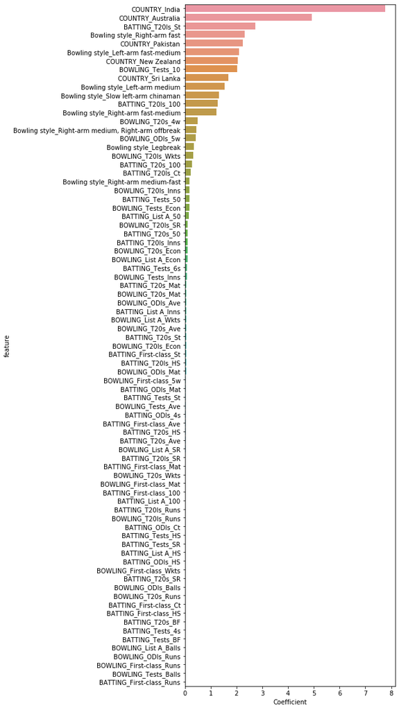

```python
import numpy as np
import seaborn as sns

coeff_visualization = pd.DataFrame( { 'feature':features, 'Coefficient': logistic.coef_[0]} )
coeff_visualization_greater_than_zero = coeff_visualization[coeff_visualization['Coefficient'] > 0 ]
coeff_visualization_less_than_zero = coeff_visualization[coeff_visualization['Coefficient'] < 0 ]

coeff_visualization_greater_than_zero = coeff_visualization_greater_than_zero.sort_values('Coefficient', ascending = False)
#first is width
plt.figure(figsize=(6, 20))
# plot the values
ax = sns.barplot( y = 'feature', x = 'Coefficient', data = coeff_visualization_greater_than_zero )
ax.figure.savefig('LogisticRegression_coefficient_greater_zero.png', bbox_inches="tight")
```

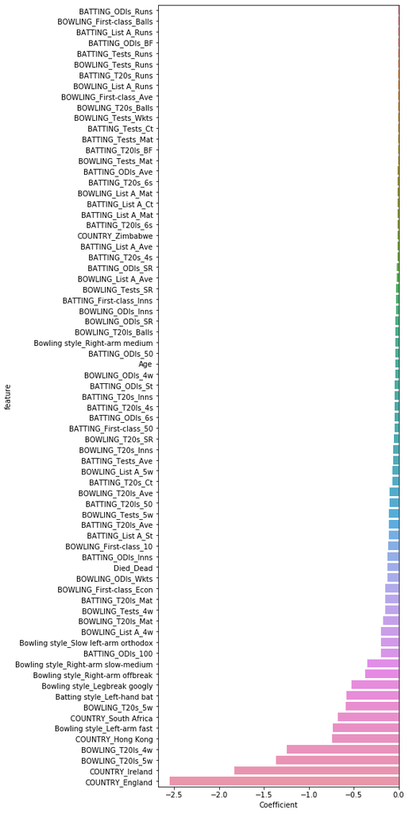

```python
coeff_visualization_less_than_zero = coeff_visualization_less_than_zero.sort_values('Coefficient', ascending = False)
plt.figure(figsize=(6, 20))
# plot the values
ax = sns.barplot( y = 'feature', x = 'Coefficient', data = coeff_visualization_less_than_zero )
ax.figure.savefig('LogisticRegression_coefficient_less_zero.png',bbox_inches="tight")
```

```python
#prediciton form the validation data
prediction = logistic.predict(X_val)
```

#### Confusion Matrix

```python
confusion_matrix_1 = confusion_matrix(y_val,prediction)
print(confusion_matrix_1)
```

```
[[3792  155]
 [  46 1947]]
```

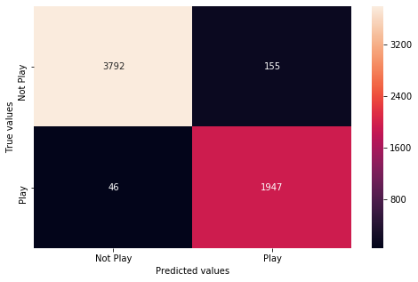

```python
plt.figure(figsize=(8,5))
c_matix = confusion_matrix_with_sns( y_val, prediction )
plt.ylabel('True values')
plt.xlabel('Predicted values')
plt.show()
c_matix.figure.savefig('Confusion_Matrix\LogisticRegression_confusion_matrix.png')
```

#### Misclassified Values

```python
print('Misclassified samples: %d' %(y_val != prediction).sum())
```

```
Misclassified samples: 201
```

```python
#calculate the accuracy
accuracy_score_1 = accuracy_score(y_val,prediction)
print('Accuracy:',accuracy_score_1)
```

```
Accuracy: 0.9661616161616161
```

#### classification Report

```python
from sklearn import metrics
print(metrics.classification_report( y_val,prediction ))
```

```
              precision    recall  f1-score   support

           0       0.99      0.96      0.97      3947
           1       0.93      0.98      0.95      1993

    accuracy                           0.97      5940
   macro avg       0.96      0.97      0.96      5940
weighted avg       0.97      0.97      0.97      5940
```

#### Roc Auc plot and score

```python
y_predict_prob = logistic.predict_proba(X_val)[:, 1]
y_predict_prob
```

```
array([3.89306361e-05, 3.05191792e-05, 9.86495903e-01, ...,
       9.99928526e-01, 9.99999215e-01, 6.63245066e-08])
```

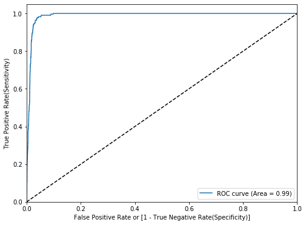

```python
plt.figure(figsize=(8, 6))
false_positive_rate, true_positive_rate, thresholds = roc_auc_plot(y_val,y_predict_prob)
plt.savefig('Roc_Auc\LogisticRegression_Roc_Auc.png')
plt.show()
```

```python
auc_score = metrics.roc_auc_score( y_val,y_predict_prob)
auc_score
```

```
0.9891303118045157
```

```python
evaluate_threshold(0.6)
```

```
Sensitivity: 0.9663823381836427
Specificity: 0.9645300228021282
```

#### Cross value score on 10 fold

```python
from sklearn.model_selection import cross_val_score
roc_score_logistic = cross_val_score(logistic, X_train_intial, y_train_intial, cv=10, scoring='roc_auc')
roc_score_logistic
```

```
array([0.99231221, 0.98811786, 0.99060101, 0.9866174 , 0.99135716,
       0.98788423, 0.99324516, 0.99362324, 0.9902317 , 0.98809871])
```

```python
print('Average roc_auc score:', np.mean(roc_score_logistic))
```

```
Average roc_auc score: 0.9902088680835126
```

```python
accuracy_logistic = cross_val_score(logistic, X_train_intial, y_train_intial, cv=10, scoring='accuracy')
accuracy_logistic
```

```
array([0.96969697, 0.96422559, 0.97222222, 0.96127946, 0.97474747,
       0.96127946, 0.96717172, 0.97053872, 0.96673684, 0.95998315])
```

```python
print('Average accuracy score:', np.mean(accuracy_logistic))
```

```
Average accuracy score: 0.9667881609067216
```

```python
from sklearn.model_selection import cross_validate
roc_accuracy = cross_validate(logistic, X_train_intial, y_train_intial, cv=10, scoring=('roc_auc','accuracy'))
```

```python
print('Average accuracy score:', np.mean(roc_accuracy['test_accuracy']))
```

```
Average accuracy score: 0.9667881609067216
```

```python
print('Average roc_auc score:', np.mean(roc_accuracy['test_roc_auc']))
```

```
Average roc_auc score: 0.9902005028514266
```

## Support Vector Classification

```python
from sklearn.svm import SVC
```

```python
svc_model = SVC(gamma='auto')
```

```python
svc_model.fit(X_train,y_train)
```

```
SVC(C=1.0, cache_size=200, class_weight=None, coef0=0.0,
    decision_function_shape='ovr', degree=3, gamma='auto', kernel='rbf',
    max_iter=-1, probability=False, random_state=None, shrinking=True,
    tol=0.001, verbose=False)
```

```python
prediction_svc = svc_model.predict(X_val)
```

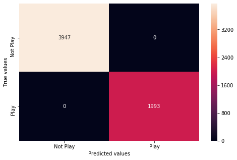

```python
plt.figure(figsize=(8,5))
c_matix = confusion_matrix_with_sns( y_val, prediction_svc )
plt.ylabel('True values')
plt.xlabel('Predicted values')
plt.show()
c_matix.figure.savefig('Confusion_Matrix\SVC_confusion_matrix.png')
```

```python
print('Misclassified samples: %d' %(y_val != prediction_svc).sum())
```

```
Misclassified samples: 0
```

```python
#calculate the accuracy
accuracy_score_1 = accuracy_score(y_val,prediction_svc)
print('Accuracy:',accuracy_score_1)
```

```
Accuracy: 1.0
```

```python
print(metrics.classification_report( y_val,prediction_svc ))
```

```
              precision    recall  f1-score   support

           0       1.00      1.00      1.00      3947
           1       1.00      1.00      1.00      1993

    accuracy                           1.00      5940
   macro avg       1.00      1.00      1.00      5940
weighted avg       1.00      1.00      1.00      5940
```

## K-nearest neighbors

```python
from sklearn.neighbors import KNeighborsClassifier
```

```python
KNN_classifer = KNeighborsClassifier()
```

```python
KNN_classifer.fit(X_train,y_train)
```

```
KNeighborsClassifier(algorithm='auto', leaf_size=30, metric='minkowski',
                     metric_params=None, n_jobs=None, n_neighbors=5, p=2,
                     weights='uniform')
```

```python
prediction_KNN = KNN_classifer.predict(X_val)
```

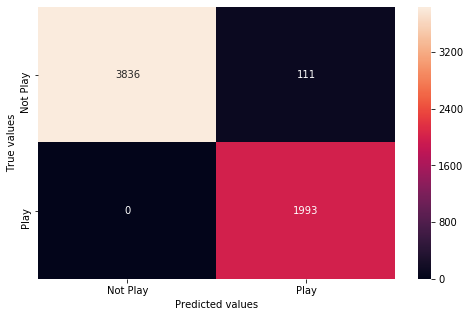

```python
plt.figure(figsize=(8,5))
c_matix = confusion_matrix_with_sns( y_val, prediction_KNN )
plt.ylabel('True values')
plt.xlabel('Predicted values')
plt.show()
c_matix.figure.savefig('Confusion_Matrix\KNN_confusion_matrix.png')
```

#### Find most optimal parameter using RandomizedSearchCV

```python
from sklearn.model_selection import RandomizedSearchCV
```

```python
important_dict = dict(n_neighbors= list(range(1, 15)), metric=['canberra', 'euclidean', 'minkowski'])
```

```python
rand = RandomizedSearchCV(KNeighborsClassifier(), important_dict, cv=10, scoring='roc_auc', random_state=0)
rand.fit(X_train_intial, y_train_intial)
```

```
RandomizedSearchCV(cv=10, error_score='raise-deprecating',
                   estimator=KNeighborsClassifier(algorithm='auto',
                                                  leaf_size=30,
                                                  metric='minkowski',
                                                  metric_params=None,
                                                  n_jobs=None, n_neighbors=5,
                                                  p=2, weights='uniform'),
                   iid='warn', n_iter=10, n_jobs=None,
                   param_distributions={'metric': ['canberra', 'euclidean',
                                                   'minkowski'],
                                        'n_neighbors': [1, 2, 3, 4, 5, 6, 7, 8,
                                                        9, 10, 11, 12, 13,
                                                        14]},
                   pre_dispatch='2*n_jobs', random_state=0, refit=True,
                   return_train_score=False, scoring='roc_auc', verbose=0)
```

```python
pd.DataFrame(rand.cv_results_)[['mean_test_score', 'std_test_score', 'params']]
```

|  | mean_test_score | std_test_score | params |
| --- | --- | --- | --- |
| 0 | 0.994164 | 0.001568 | {'n_neighbors': 3, 'metric': 'minkowski'} |
| 1 | 0.994164 | 0.001568 | {'n_neighbors': 9, 'metric': 'minkowski'} |
| 2 | 0.994164 | 0.001568 | {'n_neighbors': 14, 'metric': 'euclidean'} |
| 3 | 0.994323 | 0.001494 | {'n_neighbors': 5, 'metric': 'canberra'} |
| 4 | 0.994323 | 0.001494 | {'n_neighbors': 11, 'metric': 'canberra'} |
| 5 | 0.994164 | 0.001568 | {'n_neighbors': 12, 'metric': 'euclidean'} |
| 6 | 0.994164 | 0.001568 | {'n_neighbors': 1, 'metric': 'minkowski'} |
| 7 | 0.994323 | 0.001494 | {'n_neighbors': 12, 'metric': 'canberra'} |
| 8 | 0.994164 | 0.001568 | {'n_neighbors': 10, 'metric': 'minkowski'} |
| 9 | 0.994164 | 0.001568 | {'n_neighbors': 4, 'metric': 'minkowski'} |

```python
print(rand.best_score_)
print(rand.best_params_)
```

```
0.9943233160765448
{'n_neighbors': 5, 'metric': 'canberra'}
```

```python
best_KNN_classifer= KNeighborsClassifier(n_neighbors=5,metric='canberra')
```

```python
best_KNN_classifer.fit(X_train,y_train)
```

```
KNeighborsClassifier(algorithm='auto', leaf_size=30, metric='canberra',
                     metric_params=None, n_jobs=None, n_neighbors=5, p=2,
                     weights='uniform')
```

```python
prediction_best_KNN = best_KNN_classifer.predict(X_val)
```

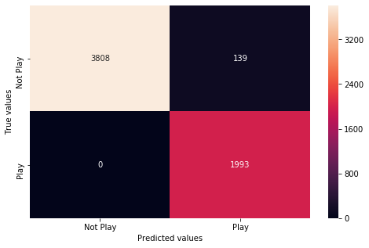

```python
plt.figure(figsize=(8,5))
c_matix = confusion_matrix_with_sns( y_val, prediction_best_KNN )
plt.ylabel('True values')
plt.xlabel('Predicted values')
plt.show()
c_matix.figure.savefig('Confusion_Matrix\Best_KNN_confusion_matrix.png')
```

```python
print('Misclassified samples: %d' %(y_val != prediction_best_KNN).sum())
```

```
Misclassified samples: 139
```

```python
#calculate the accuracy
accuracy_score_1 = accuracy_score(y_val,prediction_best_KNN)
print('Accuracy:',accuracy_score_1)
```

```
Accuracy: 0.9765993265993266
```

```python
print(metrics.classification_report( y_val,prediction_best_KNN ))
```

```
              precision    recall  f1-score   support

           0       1.00      0.96      0.98      3947
           1       0.93      1.00      0.97      1993

    accuracy                           0.98      5940
   macro avg       0.97      0.98      0.97      5940
weighted avg       0.98      0.98      0.98      5940
```

```python
y_predict_prob = best_KNN_classifer.predict_proba(X_val)[:, 1]
y_predict_prob
```

```
array([0., 0., 1., ..., 1., 1., 0.])
```

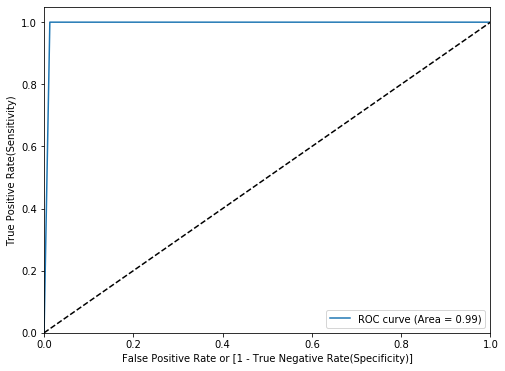

```python
plt.figure(figsize=(8, 6))
false_positive_rate, true_positive_rate, thresholds = roc_auc_plot(y_val,y_predict_prob)
plt.savefig('Roc_Auc\Best_KNN_Roc_Auc.png')
plt.show()
```

```python
auc_score = metrics.roc_auc_score( y_val,y_predict_prob)
auc_score
```

```
0.9935393970103876
```

```python
from sklearn.model_selection import cross_validate
roc_accuracy = cross_validate(best_KNN_classifer, X_train_intial, y_train_intial, cv=10, scoring=('roc_auc','accuracy'))
```

```python
print('Average accuracy score:', np.mean(roc_accuracy['test_accuracy']))
```

```
Average accuracy score: 0.9811000878140993
```

```python
print('Average roc_auc score:', np.mean(roc_accuracy['test_roc_auc']))
```

```
Average roc_auc score: 0.9943232673573575
```

## Decision Tree

```python
from sklearn import tree
```

```python
decision_tree = tree.DecisionTreeClassifier()
```

```python
decision_tree.fit(X_train,y_train)
```

```
DecisionTreeClassifier(class_weight=None, criterion='gini', max_depth=None,
                       max_features=None, max_leaf_nodes=None,
                       min_impurity_decrease=0.0, min_impurity_split=None,
                       min_samples_leaf=1, min_samples_split=2,
                       min_weight_fraction_leaf=0.0, presort=False,
                       random_state=None, splitter='best')
```

```python
prediction_decision_tree = decision_tree.predict(X_val)
```

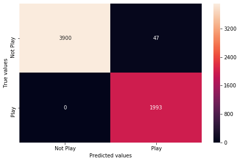

```python
plt.figure(figsize=(8,5))
c_matix = confusion_matrix_with_sns( y_val, prediction_decision_tree )
plt.ylabel('True values')
plt.xlabel('Predicted values')
plt.show()
c_matix.figure.savefig('Confusion_Matrix\Decision_Tree_confusion_matrix.png')
```

#### Find most optimal parameter using RandomizedSearchCV

```python
important_dict_decision = dict(max_depth= list(range(1, 15)), criterion=['gini', 'entropy'])
```

```python
rand = RandomizedSearchCV(decision_tree, important_dict_decision, cv=10, scoring='roc_auc', random_state=0)
rand.fit(X_train_intial, y_train_intial)
```

```
RandomizedSearchCV(cv=10, error_score='raise-deprecating',
                   estimator=DecisionTreeClassifier(class_weight=None,
                                                    criterion='gini',
                                                    max_depth=None,
                                                    max_features=None,
                                                    max_leaf_nodes=None,
                                                    min_impurity_decrease=0.0,
                                                    min_impurity_split=None,
                                                    min_samples_leaf=1,
                                                    min_samples_split=2,
                                                    min_weight_fraction_leaf=0.0,
                                                    presort=False,
                                                    random_state=None,
                                                    splitter='best'),
                   iid='warn', n_iter=10, n_jobs=None,
                   param_distributions={'criterion': ['gini', 'entropy'],
                                        'max_depth': [1, 2, 3, 4, 5, 6, 7, 8, 9,
                                                      10, 11, 12, 13, 14]},
                   pre_dispatch='2*n_jobs', random_state=0, refit=True,
                   return_train_score=False, scoring='roc_auc', verbose=0)
```

```python
print(rand.best_score_)
print(rand.best_params_)
```

```
0.9940570112314692
{'max_depth': 12, 'criterion': 'entropy'}
```

#### Find most optimal parameter using GridSearchCV

```python
from sklearn.model_selection import GridSearchCV
```

```python
important_param_decision = [{'criterion': ['gini','entropy'],'max_depth': range(1,15)}]
```

```python
grd = GridSearchCV(decision_tree,important_param_decision,cv=10,scoring='roc_auc')
grd.fit(X_train_intial, y_train_intial )
```

```
GridSearchCV(cv=10, error_score='raise-deprecating',
             estimator=DecisionTreeClassifier(class_weight=None,
                                              criterion='gini', max_depth=None,
                                              max_features=None,
                                              max_leaf_nodes=None,
                                              min_impurity_decrease=0.0,
                                              min_impurity_split=None,
                                              min_samples_leaf=1,
                                              min_samples_split=2,
                                              min_weight_fraction_leaf=0.0,
                                              presort=False, random_state=None,
                                              splitter='best'),
             iid='warn', n_jobs=None,
             param_grid=[{'criterion': ['gini', 'entropy'],
                          'max_depth': range(1, 15)}],
             pre_dispatch='2*n_jobs', refit=True, return_train_score=False,
             scoring='roc_auc', verbose=0)
```

```python
pd.DataFrame(grd.cv_results_)[['mean_test_score', 'std_test_score', 'params']]
```

|  | mean_test_score | std_test_score | params |
| --- | --- | --- | --- |
| 0 | 0.913557 | 0.006835 | {'criterion': 'gini', 'max_depth': 1} |
| 1 | 0.954199 | 0.005389 | {'criterion': 'gini', 'max_depth': 2} |
| 2 | 0.972897 | 0.004307 | {'criterion': 'gini', 'max_depth': 3} |
| 3 | 0.981097 | 0.002868 | {'criterion': 'gini', 'max_depth': 4} |
| 4 | 0.986311 | 0.002649 | {'criterion': 'gini', 'max_depth': 5} |
| 5 | 0.988775 | 0.002095 | {'criterion': 'gini', 'max_depth': 6} |
| 6 | 0.990004 | 0.002634 | {'criterion': 'gini', 'max_depth': 7} |
| 7 | 0.991211 | 0.001956 | {'criterion': 'gini', 'max_depth': 8} |
| 8 | 0.991549 | 0.001995 | {'criterion': 'gini', 'max_depth': 9} |
| 9 | 0.991031 | 0.001843 | {'criterion': 'gini', 'max_depth': 10} |
| 10 | 0.991760 | 0.001674 | {'criterion': 'gini', 'max_depth': 11} |
| 11 | 0.991349 | 0.001984 | {'criterion': 'gini', 'max_depth': 12} |
| 12 | 0.992039 | 0.001849 | {'criterion': 'gini', 'max_depth': 13} |
| 13 | 0.992155 | 0.001605 | {'criterion': 'gini', 'max_depth': 14} |
| 14 | 0.915964 | 0.004061 | {'criterion': 'entropy', 'max_depth': 1} |
| 15 | 0.957045 | 0.004263 | {'criterion': 'entropy', 'max_depth': 2} |
| 16 | 0.971649 | 0.003961 | {'criterion': 'entropy', 'max_depth': 3} |
| 17 | 0.979486 | 0.003287 | {'criterion': 'entropy', 'max_depth': 4} |
| 18 | 0.986092 | 0.002694 | {'criterion': 'entropy', 'max_depth': 5} |
| 19 | 0.989099 | 0.002167 | {'criterion': 'entropy', 'max_depth': 6} |
| 20 | 0.991058 | 0.001604 | {'criterion': 'entropy', 'max_depth': 7} |
| 21 | 0.991554 | 0.001716 | {'criterion': 'entropy', 'max_depth': 8} |
| 22 | 0.992535 | 0.001725 | {'criterion': 'entropy', 'max_depth': 9} |
| 23 | 0.993158 | 0.001128 | {'criterion': 'entropy', 'max_depth': 10} |
| 24 | 0.993962 | 0.001167 | {'criterion': 'entropy', 'max_depth': 11} |
| 25 | 0.994394 | 0.000885 | {'criterion': 'entropy', 'max_depth': 12} |
| 26 | 0.994499 | 0.000997 | {'criterion': 'entropy', 'max_depth': 13} |
| 27 | 0.994482 | 0.000928 | {'criterion': 'entropy', 'max_depth': 14} |

```python
print(grd.best_score_ )
print(grd.best_params_)
```

```
0.9944994720664788
{'criterion': 'entropy', 'max_depth': 13}
```

```python
best_decision_tree = tree.DecisionTreeClassifier(max_depth= 13, criterion= 'entropy')
best_decision_tree.fit(X_train,y_train)
```

```
DecisionTreeClassifier(class_weight=None, criterion='entropy', max_depth=13,
                       max_features=None, max_leaf_nodes=None,
                       min_impurity_decrease=0.0, min_impurity_split=None,
                       min_samples_leaf=1, min_samples_split=2,
                       min_weight_fraction_leaf=0.0, presort=False,
                       random_state=None, splitter='best')
```

```python
prediction_best_decision_tree = best_decision_tree.predict(X_val)
```

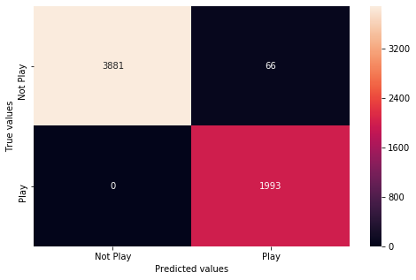

```python
plt.figure(figsize=(8,5))
c_matix = confusion_matrix_with_sns( y_val, prediction_best_decision_tree )
plt.ylabel('True values')
plt.xlabel('Predicted values')
plt.show()
c_matix.figure.savefig('Confusion_Matrix\Best_Decision_Tree_confusion_matrix.png')
```

```python
print('Misclassified samples: %d' %(y_val != prediction_best_decision_tree).sum())
```

```
Misclassified samples: 66
```

```python
#calculate the accuracy
accuracy_score_1 = accuracy_score(y_val,prediction_best_decision_tree)
print('Accuracy:',accuracy_score_1)
```

```
Accuracy: 0.9888888888888889
```

```python
print(metrics.classification_report( y_val,prediction_best_decision_tree ))
```

```
              precision    recall  f1-score   support

           0       1.00      0.98      0.99      3947
           1       0.97      1.00      0.98      1993

    accuracy                           0.99      5940
   macro avg       0.98      0.99      0.99      5940
weighted avg       0.99      0.99      0.99      5940
```

```python
y_predict_best_decision_tree = best_decision_tree.predict_proba(X_val)[:, 1]
```

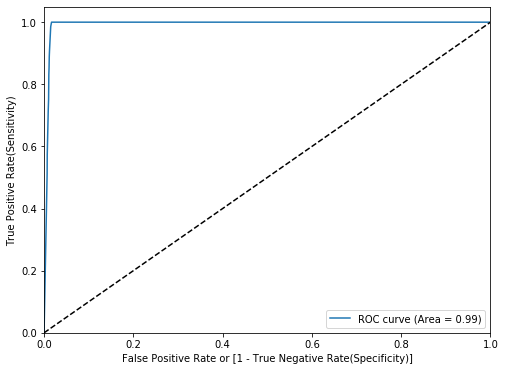

```python
plt.figure(figsize=(8, 6))
false_positive_rate, true_positive_rate, thresholds = roc_auc_plot(y_val,y_predict_best_decision_tree)
plt.savefig('Roc_Auc\Best_Decision_Tree_Roc_Auc.png')
plt.show()
```

#### Model with most optimal parameter using RandomizedSearchCV

```python
best_decision_tree_rand = tree.DecisionTreeClassifier(max_depth= 12, criterion= 'entropy')
best_decision_tree_rand.fit(X_train,y_train)
```

```
DecisionTreeClassifier(class_weight=None, criterion='entropy', max_depth=12,
                       max_features=None, max_leaf_nodes=None,
                       min_impurity_decrease=0.0, min_impurity_split=None,
                       min_samples_leaf=1, min_samples_split=2,
                       min_weight_fraction_leaf=0.0, presort=False,
                       random_state=None, splitter='best')
```

```python
prediction_best_decision_tree_rand = best_decision_tree_rand.predict(X_val)
```

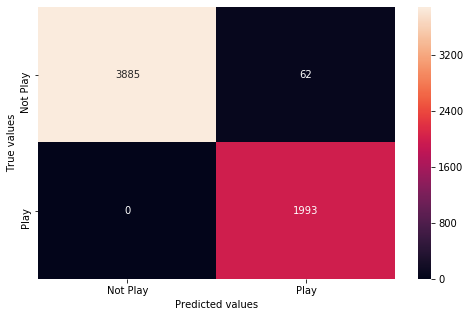

```python
plt.figure(figsize=(8,5))
c_matix = confusion_matrix_with_sns( y_val, prediction_best_decision_tree_rand )
plt.ylabel('True values')
plt.xlabel('Predicted values')
plt.show()
c_matix.figure.savefig('Confusion_Matrix\Best_Random_Decision_Tree_confusion_matrix.png')
```

```python
from sklearn.model_selection import cross_validate
roc_accuracy = cross_validate(best_decision_tree, X_train_intial, y_train_intial, cv=10, scoring=('roc_auc','accuracy'))
```

```python
print('Average accuracy score:', np.mean(roc_accuracy['test_accuracy']))
```

```
Average accuracy score: 0.9892660637023958
```

```python
print('Average roc_auc score:', np.mean(roc_accuracy['test_roc_auc']))
```

```
Average roc_auc score: 0.9943617507093082
```

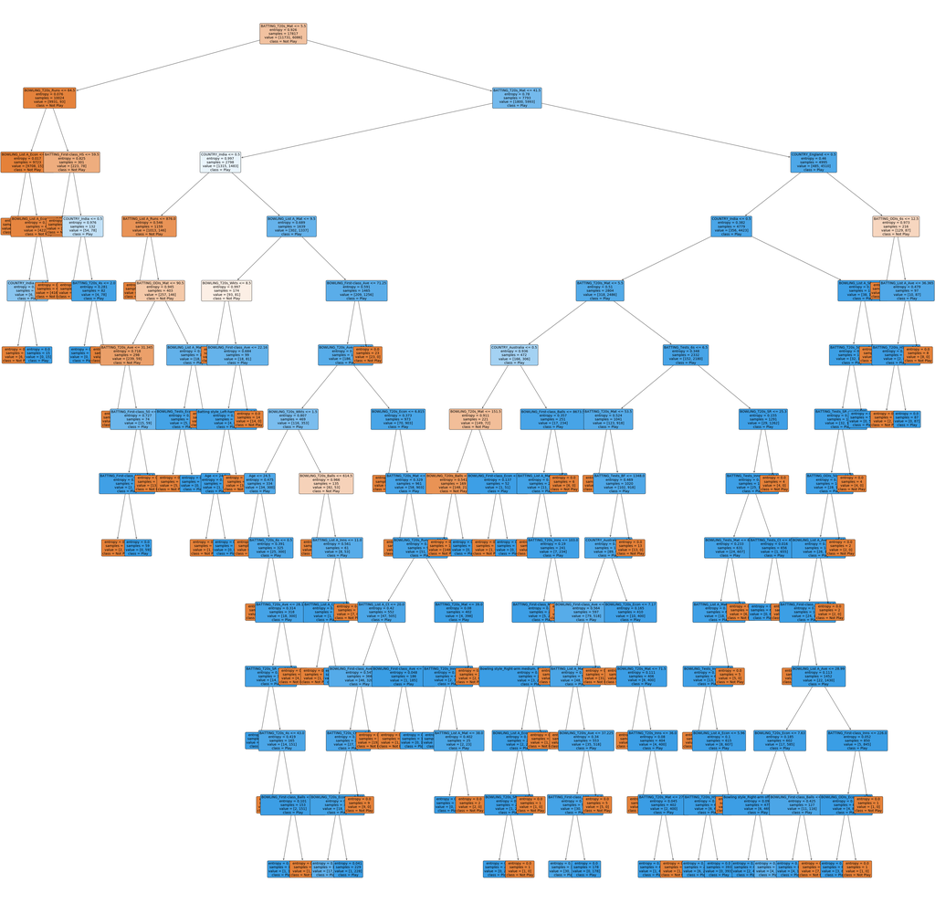

```python
from sklearn.tree import plot_tree
plt.figure(figsize=(70,70))
a= plot_tree(best_decision_tree, feature_names= features,
              class_names= ["Not Play", "Play"],
              filled=True,
              rounded=True,
              fontsize=14)
plt.savefig('Best_Decision_Tree.png')
```

## Random Forest

```python
from sklearn.ensemble import RandomForestClassifier
```

```python
radm_forest = RandomForestClassifier(n_estimators=10)
radm_forest.fit( X_train,y_train)
```

```
RandomForestClassifier(bootstrap=True, class_weight=None, criterion='gini',
                       max_depth=None, max_features='auto', max_leaf_nodes=None,
                       min_impurity_decrease=0.0, min_impurity_split=None,
                       min_samples_leaf=1, min_samples_split=2,
                       min_weight_fraction_leaf=0.0, n_estimators=10,
                       n_jobs=None, oob_score=False, random_state=None,
                       verbose=0, warm_start=False)
```

```python
prediction_random_forest = radm_forest.predict(X_val)
```

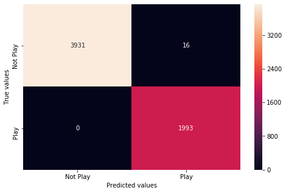

```python
plt.figure(figsize=(8,5))
c_matix = confusion_matrix_with_sns( y_val, prediction_random_forest )
plt.ylabel('True values')
plt.xlabel('Predicted values')
plt.show()
c_matix.figure.savefig('Confusion_Matrix\Random_Forest_confusion_matrix.png')
```

```python
important_dict_random_forest = dict(max_depth= list(range(1, 15)), n_estimators=list(range(10, 20)))
```

```python
find_best_radm_forest = RandomForestClassifier()
```

```python
rand = RandomizedSearchCV(find_best_radm_forest, important_dict_random_forest, cv=10, scoring='roc_auc', random_state=0)
rand.fit(X_train_intial, y_train_intial)
```

```
RandomizedSearchCV(cv=10, error_score='raise-deprecating',
                   estimator=RandomForestClassifier(bootstrap=True,
                                                    class_weight=None,
                                                    criterion='gini',
                                                    max_depth=None,
                                                    max_features='auto',
                                                    max_leaf_nodes=None,
                                                    min_impurity_decrease=0.0,
                                                    min_impurity_split=None,
                                                    min_samples_leaf=1,
                                                    min_samples_split=2,
                                                    min_weight_fraction_leaf=0.0,
                                                    n_estimators='warn',
                                                    n_jobs=None,
                                                    oob_score=False,
                                                    random_state=None,
                                                    verbose=0,
                                                    warm_start=False),
                   iid='warn', n_iter=10, n_jobs=None,
                   param_distributions={'max_depth': [1, 2, 3, 4, 5, 6, 7, 8, 9,
                                                      10, 11, 12, 13, 14],
                                        'n_estimators': [10, 11, 12, 13, 14, 15,
                                                         16, 17, 18, 19]},
                   pre_dispatch='2*n_jobs', random_state=0, refit=True,
                   return_train_score=False, scoring='roc_auc', verbose=0)
```

```python
print(rand.best_score_ )
print(rand.best_params_)
```

```
0.9998583025515595
{'n_estimators': 11, 'max_depth': 14}
```

```python
best_random_forest = RandomForestClassifier(n_estimators = 11, max_depth = 14)
best_random_forest.fit(X_train, y_train)
```

```
RandomForestClassifier(bootstrap=True, class_weight=None, criterion='gini',
                       max_depth=14, max_features='auto', max_leaf_nodes=None,
                       min_impurity_decrease=0.0, min_impurity_split=None,
                       min_samples_leaf=1, min_samples_split=2,
                       min_weight_fraction_leaf=0.0, n_estimators=11,
                       n_jobs=None, oob_score=False, random_state=None,
                       verbose=0, warm_start=False)
```

```python
prediction_best_random_forest = best_random_forest.predict(X_val)
```

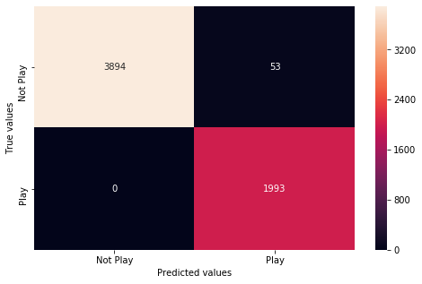

```python
plt.figure(figsize=(8,5))
c_matix = confusion_matrix_with_sns( y_val, prediction_best_random_forest )
plt.ylabel('True values')
plt.xlabel('Predicted values')
plt.show()
c_matix.figure.savefig('Confusion_Matrix\Best_Random_Forest_confusion_matrix.png')
```

```python
print('Misclassified samples: %d' %(y_val != prediction_best_random_forest).sum())
```

```
Misclassified samples: 53
```

```python
#calculate the accuracy
accuracy_score_1 = accuracy_score(y_val,prediction_best_random_forest)
print('Accuracy:',accuracy_score_1)
```

```
Accuracy: 0.9910774410774411
```

```python
print(metrics.classification_report( y_val,prediction_best_random_forest ))
```

```
              precision    recall  f1-score   support

           0       1.00      0.99      0.99      3947
           1       0.97      1.00      0.99      1993

    accuracy                           0.99      5940
   macro avg       0.99      0.99      0.99      5940
weighted avg       0.99      0.99      0.99      5940
```

```python
y_predict_best_random_forest = best_random_forest.predict_proba(X_val)[:, 1]
```

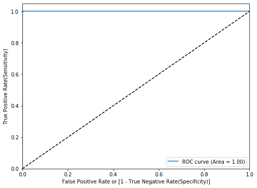

```python
plt.figure(figsize=(8, 6))
false_positive_rate, true_positive_rate, thresholds = roc_auc_plot(y_val,y_predict_best_random_forest)
plt.savefig('Roc_Auc\Best_Random_Forest_Roc_Auc.png')
plt.show()
```

```python
evaluate_threshold(0)
```

```
Sensitivity: 1.0
Specificity: 0.896883709146187
```

```python
from sklearn.model_selection import cross_validate
roc_accuracy = cross_validate(best_random_forest, X_train_intial, y_train_intial, cv=10, scoring=('roc_auc','accuracy'))
```

```python
print('Average accuracy score:', np.mean(roc_accuracy['test_accuracy']))
```

```
Average accuracy score: 0.9904026400363917
```

```python
print('Average roc_auc score:', np.mean(roc_accuracy['test_roc_auc']))
```

```
Average roc_auc score: 0.9998675545197665
```

## Stochastic Gradient Descent

```python
from sklearn.linear_model import SGDClassifier
SGD_Model = SGDClassifier(loss="log", penalty="l2")
SGD_Model.fit(X_train,y_train)
```

```
SGDClassifier(alpha=0.0001, average=False, class_weight=None,
              early_stopping=False, epsilon=0.1, eta0=0.0, fit_intercept=True,
              l1_ratio=0.15, learning_rate='optimal', loss='log', max_iter=1000,
              n_iter_no_change=5, n_jobs=None, penalty='l2', power_t=0.5,
              random_state=None, shuffle=True, tol=0.001,
              validation_fraction=0.1, verbose=0, warm_start=False)
```

```python
prediction_sgd = SGD_Model.predict(X_val)
```

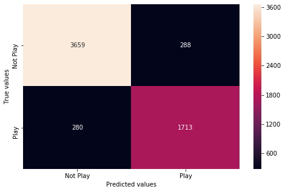

```python
plt.figure(figsize=(8,5))
c_matix = confusion_matrix_with_sns( y_val, prediction_sgd )
plt.ylabel('True values')
plt.xlabel('Predicted values')
plt.show()
c_matix.figure.savefig('Confusion_Matrix\stochastic_gradient_confusion_matrix.png')
```

```python
from sklearn.model_selection import GridSearchCV
```

```python
Find_best_SGD_Model = SGDClassifier()
```

```python
important_param_sgd = [{'loss': ['hinge', 'log', 'modified_huber', 'squared_hinge'],'penalty': ['l2','l1']}]
grd = GridSearchCV(Find_best_SGD_Model,important_param_sgd,cv=10,scoring='roc_auc')
grd.fit(X_train_intial, y_train_intial )
```

```
GridSearchCV(cv=10, error_score='raise-deprecating',
             estimator=SGDClassifier(alpha=0.0001, average=False,
                                     class_weight=None, early_stopping=False,
                                     epsilon=0.1, eta0=0.0, fit_intercept=True,
                                     l1_ratio=0.15, learning_rate='optimal',
                                     loss='hinge', max_iter=1000,
                                     n_iter_no_change=5, n_jobs=None,
                                     penalty='l2', power_t=0.5,
                                     random_state=None, shuffle=True, tol=0.001,
                                     validation_fraction=0.1, verbose=0,
                                     warm_start=False),
             iid='warn', n_jobs=None,
             param_grid=[{'loss': ['hinge', 'log', 'modified_huber',
                                   'squared_hinge'],
                          'penalty': ['l2', 'l1']}],
             pre_dispatch='2*n_jobs', refit=True, return_train_score=False,
             scoring='roc_auc', verbose=0)
```

```python
print(grd.best_score_ )
print(grd.best_params_)
```

```
0.9647148845396482
{'loss': 'modified_huber', 'penalty': 'l1'}
```

```python
pd.DataFrame(grd.cv_results_)[['mean_test_score', 'std_test_score', 'params']]
```

|  | mean_test_score | std_test_score | params |
| --- | --- | --- | --- |
| 0 | 0.897202 | 0.055271 | {'loss': 'hinge', 'penalty': 'l2'} |
| 1 | 0.963889 | 0.005428 | {'loss': 'hinge', 'penalty': 'l1'} |
| 2 | 0.941264 | 0.049196 | {'loss': 'log', 'penalty': 'l2'} |
| 3 | 0.961946 | 0.006666 | {'loss': 'log', 'penalty': 'l1'} |
| 4 | 0.898905 | 0.053914 | {'loss': 'modified_huber', 'penalty': 'l2'} |
| 5 | 0.964715 | 0.004469 | {'loss': 'modified_huber', 'penalty': 'l1'} |
| 6 | 0.907402 | 0.049815 | {'loss': 'squared_hinge', 'penalty': 'l2'} |
| 7 | 0.949656 | 0.035004 | {'loss': 'squared_hinge', 'penalty': 'l1'} |

```python
Best_SGD_Model = SGDClassifier(loss='modified_huber', penalty="l1")
```

```python
Best_SGD_Model.fit(X_train,y_train)
```

```
SGDClassifier(alpha=0.0001, average=False, class_weight=None,
              early_stopping=False, epsilon=0.1, eta0=0.0, fit_intercept=True,
              l1_ratio=0.15, learning_rate='optimal', loss='modified_huber',
              max_iter=1000, n_iter_no_change=5, n_jobs=None, penalty='l1',
              power_t=0.5, random_state=None, shuffle=True, tol=0.001,
              validation_fraction=0.1, verbose=0, warm_start=False)
```

```python
prediction_best_sgd = Best_SGD_Model.predict(X_val)
```

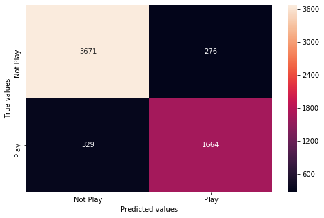

```python
plt.figure(figsize=(8,5))
c_matix = confusion_matrix_with_sns( y_val, prediction_best_sgd )
plt.ylabel('True values')
plt.xlabel('Predicted values')
plt.show()
c_matix.figure.savefig('Confusion_Matrix\Best_stochastic_gradient_confusion_matrix.png')
```

```python
print('Misclassified samples: %d' %(y_val != prediction_best_sgd).sum())
```

```
Misclassified samples: 605
```

```python
#calculate the accuracy
accuracy_score_1 = accuracy_score(y_val,prediction_best_sgd)
print('Accuracy:',accuracy_score_1)
```

```
Accuracy: 0.8981481481481481
```

```python
print(metrics.classification_report( y_val,prediction_best_sgd ))
```

```
              precision    recall  f1-score   support

           0       0.92      0.93      0.92      3947
           1       0.86      0.83      0.85      1993

    accuracy                           0.90      5940
   macro avg       0.89      0.88      0.89      5940
weighted avg       0.90      0.90      0.90      5940
```

```python
y_predict_best_sgd = Best_SGD_Model.predict_proba(X_val)[:, 1]
```

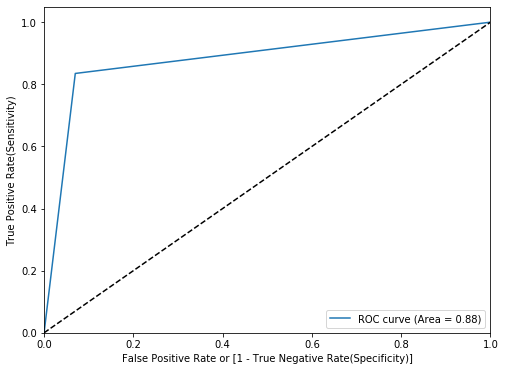

```python
plt.figure(figsize=(8, 6))
false_positive_rate, true_positive_rate, thresholds = roc_auc_plot(y_val,y_predict_best_sgd)
plt.savefig('Roc_Auc\Best_stochastic_gradient_Roc_Auc.png')
plt.show()
```

```python
from sklearn.model_selection import cross_validate
roc_accuracy = cross_validate(Best_SGD_Model, X_train_intial, y_train_intial, cv=10, scoring=('roc_auc','accuracy'))
```

```python
print('Average accuracy score:', np.mean(roc_accuracy['test_accuracy']))
```

```
Average accuracy score: 0.8999867763491938
```

```python
print('Average roc_auc score:', np.mean(roc_accuracy['test_roc_auc']))
```

```
Average roc_auc score: 0.9643176837720349
```

## Gaussian Processes classification - took so long

```python
from sklearn.gaussian_process import GaussianProcessClassifier
from sklearn.gaussian_process.kernels import RBF
```

```python
# gpc = GaussianProcessClassifier()
# gpc.fit(X_train,y_train)
```

```python
# prediction_gpc = gpc.predict(X_val)
```

```python
# plt.figure(figsize=(8,5))
# c_matix = confusion_matrix_with_sns( y_val, prediction_gpc )
# plt.ylabel('True values')
# plt.xlabel('Predicted values')
# plt.show()
# c_matix.figure.savefig('Confusion_Matrix\Gaussian_processes_confusion_matrix.png')
```

## Naive Bayes

```python
from sklearn.naive_bayes import GaussianNB
nb = GaussianNB()
nb.fit(X_train,y_train)
```

```
GaussianNB(priors=None, var_smoothing=1e-09)
```

```python
prediction_nb = nb.predict(X_val)
```

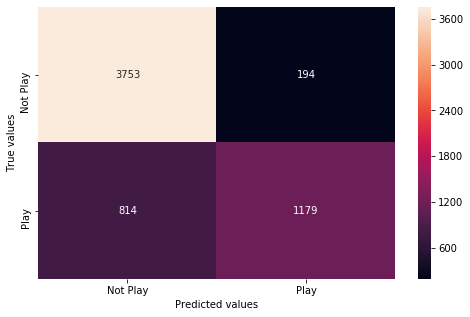

```python
plt.figure(figsize=(8,5))
c_matix = confusion_matrix_with_sns( y_val, prediction_nb )
plt.ylabel('True values')
plt.xlabel('Predicted values')
plt.show()
c_matix.figure.savefig('Confusion_Matrix\c_naive_Bayes_confusion_matrix.png')
```

```python
print('Misclassified samples: %d' %(y_val != prediction_nb).sum())
```

```
Misclassified samples: 1008
```

```python
#calculate the accuracy
accuracy_score_1 = accuracy_score(y_val,prediction_nb)
print('Accuracy:',accuracy_score_1)
```

```
Accuracy: 0.8303030303030303
```

```python
from sklearn import metrics
print(metrics.classification_report( y_val,prediction_nb ))
```

```
              precision    recall  f1-score   support

           0       0.82      0.95      0.88      3947
           1       0.86      0.59      0.70      1993

    accuracy                           0.83      5940
   macro avg       0.84      0.77      0.79      5940
weighted avg       0.83      0.83      0.82      5940
```

```python
y_predict_nb = nb.predict_proba(X_val)[:, 1]
```

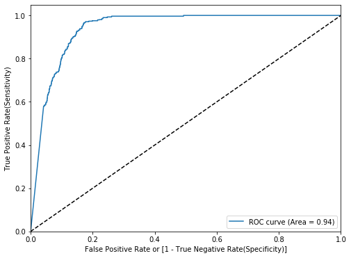

```python
plt.figure(figsize=(8, 6))
false_positive_rate, true_positive_rate, thresholds = roc_auc_plot(y_val,y_predict_nb)
plt.savefig('Roc_Auc\c_Naive_Bayes_Roc_Auc.png')
plt.show()
```

```python
from sklearn.model_selection import cross_val_score
cross_val_score(nb, X_train_intial,y_train_intial, cv = 10, scoring = 'roc_auc' )
```

```
array([0.94062524, 0.93974714, 0.9344533 , 0.93524063, 0.93468851,
       0.93834218, 0.94382783, 0.94014061, 0.93520917, 0.93616718])
```

```python
from sklearn.model_selection import cross_validate
roc_accuracy = cross_validate(nb, X_train_intial, y_train_intial, cv=10, scoring=('roc_auc','accuracy'))
```

```python
print('Average accuracy score:', np.mean(roc_accuracy['test_accuracy']))
```

```
Average accuracy score: 0.8217367471400328
```

```python
print('Average roc_auc score:', np.mean(roc_accuracy['test_roc_auc']))
```

```
Average roc_auc score: 0.9378441782804453
```

## Adaboost

```python
from sklearn.ensemble import AdaBoostClassifier
from sklearn import tree
d_tree = tree.DecisionTreeClassifier(max_depth= 12, criterion= 'entropy')
ada = AdaBoostClassifier(d_tree)
```

```python
ada.fit(X_train,y_train )
```

```
AdaBoostClassifier(algorithm='SAMME.R',
                   base_estimator=DecisionTreeClassifier(class_weight=None,
                                                         criterion='entropy',
                                                         max_depth=12,
                                                         max_features=None,
                                                         max_leaf_nodes=None,
                                                         min_impurity_decrease=0.0,
                                                         min_impurity_split=None,
                                                         min_samples_leaf=1,
                                                         min_samples_split=2,
                                                         min_weight_fraction_leaf=0.0,
                                                         presort=False,
                                                         random_state=None,
                                                         splitter='best'),
                   learning_rate=1.0, n_estimators=50, random_state=None)
```

```python
prediction_ada = ada.predict(X_val)
```

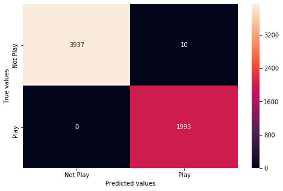

```python
plt.figure(figsize=(8,5))
c_matix = confusion_matrix_with_sns( y_val, prediction_ada )
plt.ylabel('True values')
plt.xlabel('Predicted values')
plt.show()
c_matix.figure.savefig('Confusion_Matrix\Adaboost_confusion_matrix.png')
```

```python
print('Misclassified samples: %d' %(y_val != prediction_ada).sum())
```

```
Misclassified samples: 10
```

```python
#calculate the accuracy
accuracy_score_1 = accuracy_score(y_val,prediction_ada)
print('Accuracy:',accuracy_score_1)
```

```
Accuracy: 0.9983164983164983
```

```python
from sklearn import metrics
print(metrics.classification_report( y_val,prediction_ada ))
```

```
              precision    recall  f1-score   support

           0       1.00      1.00      1.00      3947
           1       1.00      1.00      1.00      1993

    accuracy                           1.00      5940
   macro avg       1.00      1.00      1.00      5940
weighted avg       1.00      1.00      1.00      5940
```

```python
y_predict_ada = ada.predict_proba(X_val)[:, 1]
```

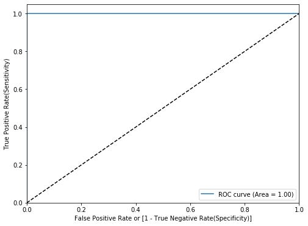

```python
plt.figure(figsize=(8, 6))
false_positive_rate, true_positive_rate, thresholds = roc_auc_plot(y_val,y_predict_ada)
plt.savefig('Roc_Auc\Adaboost_Roc_Auc.png')
plt.show()
```

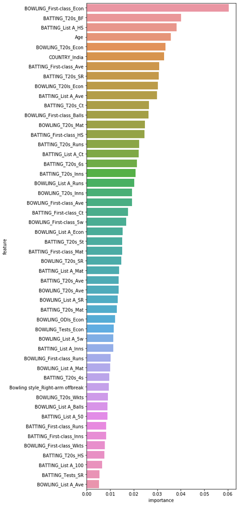

```python
import numpy as np
import seaborn as sns

imp_feature = pd.DataFrame( { 'feature':features,'importance':  ada.feature_importances_} )

imp_feature = imp_feature.sort_values('importance', ascending = False)[:50]

#first is width
plt.figure(figsize=(6, 20))
# plot the values
ax = sns.barplot( y = 'feature', x = 'importance', data = imp_feature )
ax.figure.savefig('ada_important_features.png',bbox_inches="tight")
```

```python
from sklearn.model_selection import cross_val_score
cross_val_score( ada, X_train_intial,y_train_intial, cv = 10, scoring = 'roc_auc' )
```

```
array([1., 1., 1., 1., 1., 1., 1., 1., 1., 1.])
```

```python
from sklearn.model_selection import cross_validate
roc_accuracy = cross_validate(ada, X_train_intial, y_train_intial, cv=10, scoring=('roc_auc','accuracy'))
```

```python
print('Average accuracy score:', np.mean(roc_accuracy['test_accuracy']))
```

```
Average accuracy score: 0.9989055998283728
```

```python
print('Average roc_auc score:', np.mean(roc_accuracy['test_roc_auc']))
```

```
Average roc_auc score: 1.0
```

## Gradient Boosting

```python
from sklearn.ensemble import GradientBoostingClassifier
gboost = GradientBoostingClassifier()
gboost.fit(X_train,y_train )
```

```
GradientBoostingClassifier(criterion='friedman_mse', init=None,
                           learning_rate=0.1, loss='deviance', max_depth=3,
                           max_features=None, max_leaf_nodes=None,
                           min_impurity_decrease=0.0, min_impurity_split=None,
                           min_samples_leaf=1, min_samples_split=2,
                           min_weight_fraction_leaf=0.0, n_estimators=100,
                           n_iter_no_change=None, presort='auto',
                           random_state=None, subsample=1.0, tol=0.0001,
                           validation_fraction=0.1, verbose=0,
                           warm_start=False)
```

```python
prediction_gboost = gboost.predict(X_val)
```

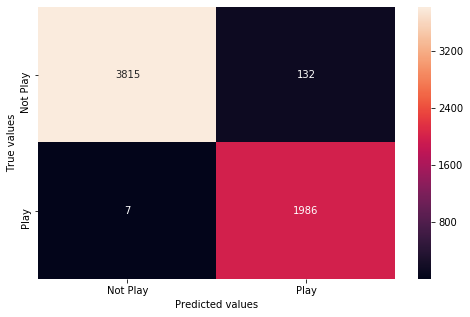

```python
plt.figure(figsize=(8,5))
c_matix = confusion_matrix_with_sns( y_val, prediction_gboost )
plt.ylabel('True values')
plt.xlabel('Predicted values')
plt.show()
c_matix.figure.savefig('Confusion_Matrix\Gradient_boost_confusion_matrix.png')
```

```python
print('Misclassified samples: %d' %(y_val != prediction_gboost).sum())
```

```
Misclassified samples: 139
```

```python
#calculate the accuracy
accuracy_score_1 = accuracy_score(y_val,prediction_gboost)
print('Accuracy:',accuracy_score_1)
```

```
Accuracy: 0.9765993265993266
```

```python
from sklearn import metrics
print(metrics.classification_report( y_val,prediction_gboost ))
```

```
              precision    recall  f1-score   support

           0       1.00      0.97      0.98      3947
           1       0.94      1.00      0.97      1993

    accuracy                           0.98      5940
   macro avg       0.97      0.98      0.97      5940
weighted avg       0.98      0.98      0.98      5940
```

```python
y_predict_gboost = gboost.predict_proba(X_val)[:, 1]
```

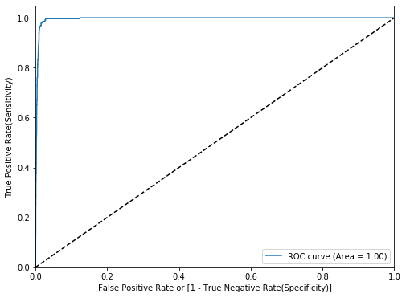

```python
plt.figure(figsize=(8, 6))
false_positive_rate, true_positive_rate, thresholds = roc_auc_plot(y_val,y_predict_gboost)
plt.savefig('Roc_Auc\Gradient_boost_Roc_Auc.png')
plt.show()
```

```python
from sklearn.model_selection import cross_val_score
cross_val_score(gboost, X_train_intial,y_train_intial, cv = 10, scoring = 'roc_auc' )
```

```
array([0.99705906, 0.99647538, 0.99579776, 0.99563438, 0.99586327,
       0.99505187, 0.99747424, 0.99781048, 0.99396194, 0.99439097])
```

```python
from sklearn.model_selection import cross_validate
roc_accuracy = cross_validate(gboost, X_train_intial, y_train_intial, cv=10, scoring=('roc_auc','accuracy'))
```

```python
print('Average accuracy score:', np.mean(roc_accuracy['test_accuracy']))
```

```
Average accuracy score: 0.9795844576956847
```

```python
print('Average roc_auc score:', np.mean(roc_accuracy['test_roc_auc']))
```

```
Average roc_auc score: 0.9959131813291335
```

## Histogram-Based Gradient Boosting

```python
from sklearn.experimental import enable_hist_gradient_boosting
from sklearn.ensemble import HistGradientBoostingClassifier
hbgb = HistGradientBoostingClassifier()
hbgb.fit(X_train,y_train )
```

```
HistGradientBoostingClassifier(l2_regularization=0.0, learning_rate=0.1,
                               loss='auto', max_bins=256, max_depth=None,
                               max_iter=100, max_leaf_nodes=31,
                               min_samples_leaf=20, n_iter_no_change=None,
                               random_state=None, scoring=None, tol=1e-07,
                               validation_fraction=0.1, verbose=0)
```

```python
prediction_hbgb = hbgb.predict(X_val)
```

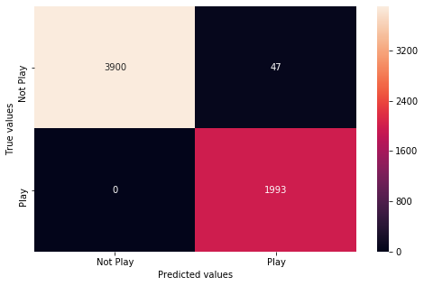

```python
plt.figure(figsize=(8,5))
c_matix = confusion_matrix_with_sns( y_val, prediction_hbgb )
plt.ylabel('True values')
plt.xlabel('Predicted values')
plt.show()
c_matix.figure.savefig('Confusion_Matrix\Histogram_Gradient_boost_confusion_matrix.png')
```

```python
print('Misclassified samples: %d' %(y_val != prediction_hbgb).sum())
```

```
Misclassified samples: 47
```

```python
accuracy_score_1 = accuracy_score(y_val,prediction_hbgb)
print('Accuracy:',accuracy_score_1)
```

```
Accuracy: 0.9920875420875421
```

```python
from sklearn import metrics
print(metrics.classification_report( y_val,prediction_hbgb ))
```

```
              precision    recall  f1-score   support

           0       1.00      0.99      0.99      3947
           1       0.98      1.00      0.99      1993

    accuracy                           0.99      5940
   macro avg       0.99      0.99      0.99      5940
weighted avg       0.99      0.99      0.99      5940
```

```python
y_predict_hbgb = hbgb.predict_proba(X_val)[:, 1]
```

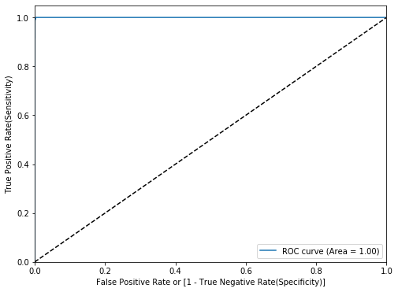

```python
plt.figure(figsize=(8, 6))
false_positive_rate, true_positive_rate, thresholds = roc_auc_plot(y_val,y_predict_hbgb)
plt.savefig('Roc_Auc\Histogram_Gradient_boost_Roc_Auc.png')
plt.show()
```

```python
from sklearn.model_selection import cross_val_score
cross_val_score(hbgb, X_train_intial,y_train_intial, cv = 10, scoring = 'roc_auc' )
```

```
array([1.        , 0.99927937, 0.99965508, 0.99998816, 0.99999526,
       0.99997869, 0.99999842, 1.        , 0.99992892, 0.99966787])
```

```python
from sklearn.model_selection import cross_validate
roc_accuracy = cross_validate(hbgb, X_train_intial, y_train_intial, cv=10, scoring=('roc_auc','accuracy'))
```

```python
print('Average accuracy score:', np.mean(roc_accuracy['test_accuracy']))
```

```
Average accuracy score: 0.9936014704606777
```

```python
print('Average roc_auc score:', np.mean(roc_accuracy['test_roc_auc']))
```

```
Average roc_auc score: 0.99984917674018
```

## Neural network models

```python
from sklearn.neural_network import MLPClassifier
nn = MLPClassifier(solver='lbfgs', alpha=1e-5, hidden_layer_sizes=(289,100,50), random_state=1)
nn.fit(X_train,y_train )
```

```
MLPClassifier(activation='relu', alpha=1e-05, batch_size='auto', beta_1=0.9,
              beta_2=0.999, early_stopping=False, epsilon=1e-08,
              hidden_layer_sizes=(289, 100, 50), learning_rate='constant',
              learning_rate_init=0.001, max_iter=200, momentum=0.9,
              n_iter_no_change=10, nesterovs_momentum=True, power_t=0.5,
              random_state=1, shuffle=True, solver='lbfgs', tol=0.0001,
              validation_fraction=0.1, verbose=False, warm_start=False)
```

```python
prediction_nn = nn.predict(X_val)
```

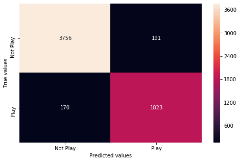

```python
plt.figure(figsize=(8,5))
c_matix = confusion_matrix_with_sns( y_val, prediction_nn )
plt.ylabel('True values')
plt.xlabel('Predicted values')
plt.show()
c_matix.figure.savefig('Confusion_Matrix\c_Neural_network_confusion_matrix.png')
```

```python
from sklearn.model_selection import GridSearchCV
important_param = [{'hidden_layer_sizes': [(100,50,5), (100,50), (100,)],'solver': ['lbfgs','sgd']}]
grd = GridSearchCV(nn,important_param,cv=10,scoring='roc_auc')
grd.fit(X_train_intial, y_train_intial )
```

```
GridSearchCV(cv=10, error_score='raise-deprecating',
             estimator=MLPClassifier(activation='relu', alpha=1e-05,
                                     batch_size='auto', beta_1=0.9,
                                     beta_2=0.999, early_stopping=False,
                                     epsilon=1e-08,
                                     hidden_layer_sizes=(289, 100, 50),
                                     learning_rate='constant',
                                     learning_rate_init=0.001, max_iter=200,
                                     momentum=0.9, n_iter_no_change=10,
                                     nesterovs_momentum=True, power_t=0.5,
                                     random_state=1, shuffle=True,
                                     solver='lbfgs', tol=0.0001,
                                     validation_fraction=0.1, verbose=False,
                                     warm_start=False),
             iid='warn', n_jobs=None,
             param_grid=[{'hidden_layer_sizes': [(100, 50, 5), (100, 50),
                                                 (100,)],
                          'solver': ['lbfgs', 'sgd']}],
             pre_dispatch='2*n_jobs', refit=True, return_train_score=False,
             scoring='roc_auc', verbose=0)
```

```python
print(grd.best_score_ )
print(grd.best_params_)
```

```
0.9771378185835454
{'hidden_layer_sizes': (100,), 'solver': 'lbfgs'}
```

```python
pd.DataFrame(grd.cv_results_)[['mean_test_score', 'std_test_score', 'params']]
```

|  | mean_test_score | std_test_score | params |
| --- | --- | --- | --- |
| 0 | 0.618469 | 0.024486 | {'hidden_layer_sizes': (100, 50, 5), 'solver':... |
| 1 | 0.499968 | 0.000096 | {'hidden_layer_sizes': (100, 50, 5), 'solver':... |
| 2 | 0.973997 | 0.003841 | {'hidden_layer_sizes': (100, 50), 'solver': 'l... |
| 3 | 0.532864 | 0.051271 | {'hidden_layer_sizes': (100, 50), 'solver': 's... |
| 4 | 0.977138 | 0.002187 | {'hidden_layer_sizes': (100,), 'solver': 'lbfgs'} |
| 5 | 0.909445 | 0.040890 | {'hidden_layer_sizes': (100,), 'solver': 'sgd'} |

```python
best_nn = MLPClassifier(solver='lbfgs', alpha=1e-5, hidden_layer_sizes=(100,), random_state=1)
best_nn.fit(X_train,y_train )
```

```
MLPClassifier(activation='relu', alpha=1e-05, batch_size='auto', beta_1=0.9,
              beta_2=0.999, early_stopping=False, epsilon=1e-08,
              hidden_layer_sizes=(100,), learning_rate='constant',
              learning_rate_init=0.001, max_iter=200, momentum=0.9,
              n_iter_no_change=10, nesterovs_momentum=True, power_t=0.5,
              random_state=1, shuffle=True, solver='lbfgs', tol=0.0001,
              validation_fraction=0.1, verbose=False, warm_start=False)
```

```python
prediction_best_nn = best_nn.predict(X_val)
```

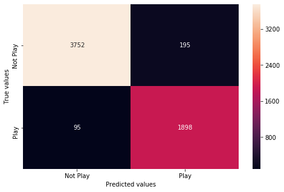

```python
plt.figure(figsize=(8,5))
c_matix = confusion_matrix_with_sns( y_val, prediction_best_nn )
plt.ylabel('True values')
plt.xlabel('Predicted values')
plt.show()
c_matix.figure.savefig('Confusion_Matrix\Best_Neural_network_confusion_matrix.png')
```

```python
print('Misclassified samples: %d' %(y_val != prediction_best_nn).sum())
```

```
Misclassified samples: 290
```

```python
#calculate the accuracy
accuracy_score_1 = accuracy_score(y_val,prediction_best_nn)
print('Accuracy:',accuracy_score_1)
```

```
Accuracy: 0.9511784511784511
```

```python
from sklearn import metrics
print(metrics.classification_report( y_val,prediction_best_nn ))
```

```
              precision    recall  f1-score   support

           0       0.98      0.95      0.96      3947
           1       0.91      0.95      0.93      1993

    accuracy                           0.95      5940
   macro avg       0.94      0.95      0.95      5940
weighted avg       0.95      0.95      0.95      5940
```

```python
y_predict_nn = best_nn.predict_proba(X_val)[:, 1]
```

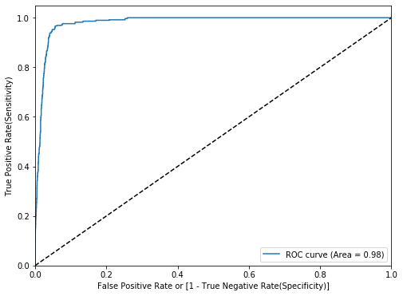

```python
plt.figure(figsize=(8, 6))
false_positive_rate, true_positive_rate, thresholds = roc_auc_plot(y_val,y_predict_nn)
plt.savefig('Roc_Auc\Best_Neural_network_Roc_Auc.png')
plt.show()
```

```python
from sklearn.model_selection import cross_validate
roc_accuracy = cross_validate(best_nn, X_train_intial, y_train_intial, cv=10, scoring=('roc_auc','accuracy'))
```

```python
print('Average accuracy score:', np.mean(roc_accuracy['test_accuracy']))
```

```
Average accuracy score: 0.9396382220048516
```

```python
print('Average roc_auc score:', np.mean(roc_accuracy['test_roc_auc']))
```

```
Average roc_auc score: 0.9771375914754141
```

## Voting Classifier on Validation Dataset

```python
from sklearn import tree
from sklearn.ensemble import RandomForestClassifier
from sklearn.ensemble import AdaBoostClassifier
from sklearn.experimental import enable_hist_gradient_boosting
from sklearn.ensemble import HistGradientBoostingClassifier
from sklearn.ensemble import VotingRegressor
random_forest_classifer  = RandomForestClassifier(n_estimators = 11, max_depth = 14)
d_tree = tree.DecisionTreeClassifier(max_depth= 12, criterion= 'entropy')
ada_classifer = AdaBoostClassifier(d_tree)
hbgb_classifer = HistGradientBoostingClassifier()
vr_classifer = VotingRegressor(estimators=[('rf', random_forest_classifer), ('ada', ada_classifer), ('hbgb', hbgb_classifer)])
```

```python
vr_classifer.fit(X_train,y_train)
```

```
VotingRegressor(estimators=[('rf',
                             RandomForestClassifier(bootstrap=True,
                                                    class_weight=None,
                                                    criterion='gini',
                                                    max_depth=14,
                                                    max_features='auto',
                                                    max_leaf_nodes=None,
                                                    min_impurity_decrease=0.0,
                                                    min_impurity_split=None,
                                                    min_samples_leaf=1,
                                                    min_samples_split=2,
                                                    min_weight_fraction_leaf=0.0,
                                                    n_estimators=11,
                                                    n_jobs=None,
                                                    oob_score=False,
                                                    random_state=None,
                                                    verbose=0,...
                                                                                      splitter='best'),
                                                learning_rate=1.0,
                                                n_estimators=50,
                                                random_state=None)),
                            ('hbgb',
                             HistGradientBoostingClassifier(l2_regularization=0.0,
                                                            learning_rate=0.1,
                                                            loss='auto',
                                                            max_bins=256,
                                                            max_depth=None,
                                                            max_iter=100,
                                                            max_leaf_nodes=31,
                                                            min_samples_leaf=20,
                                                            n_iter_no_change=None,
                                                            random_state=None,
                                                            scoring=None,
                                                            tol=1e-07,
                                                            validation_fraction=0.1,
                                                            verbose=0))],
                n_jobs=None, weights=None)
```

```python
prediction_vr_classifer = vr_classifer.predict(X_val)
```

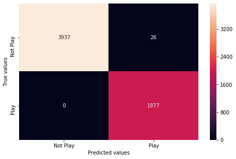

```python
plt.figure(figsize=(8,5))
c_matix = confusion_matrix_with_sns( y_val, prediction_vr_classifer.round() )
plt.ylabel('True values')
plt.xlabel('Predicted values')
plt.show()
c_matix.figure.savefig('Confusion_Matrix\Vr_classifer_confusion_matrix.png')
```

```python
print('Misclassified samples: %d' %(y_val != prediction_vr_classifer.round()).sum())
```

```
Misclassified samples: 26
```

```python
#calculate the accuracy
accuracy_score_1 = accuracy_score(y_val,prediction_vr_classifer.round())
print('Accuracy:',accuracy_score_1)
```

```
Accuracy: 0.9956228956228956
```

```python
from sklearn import metrics
print(metrics.classification_report( y_val,prediction_vr_classifer.round() ))
```

```
              precision    recall  f1-score   support

           0       1.00      0.99      1.00      3963
           1       0.99      1.00      0.99      1977

    accuracy                           1.00      5940
   macro avg       0.99      1.00      1.00      5940
weighted avg       1.00      1.00      1.00      5940
```

```python
from sklearn.model_selection import cross_val_score
roc_accuracy  = cross_val_score(vr_classifer, X_train_intial,y_train_intial, cv = 10, scoring = 'roc_auc' )
```

```python
print('Average roc_auc score:', np.mean(roc_accuracy))
```

```
Average roc_auc score: 0.999206974326345
```